Cypress Marrs & Briana Cervantes

10/22/2021

# Modeling Home Prices In Boulder County, CO

## Introduction

### Predictors

In the fifteen years since its founding in 2006, Zillow has become synonymous with high-quality home price predictions. Following the national reckoning with the myriad of ways racism is embedded into American culture during the summer of 2020, many people within Zillow began questioning our product’s reliance on data collected by police departments. To this end, our research group has spent the last few weeks exploring alternative indicators that might be used to replace crime data. We developed these metrics within Boulder County, CO. Although the model we developed lacks the predictive power of Zillow’s current model, we hope that our work on alternative indicators may become a leader again, this time in prioritizing the public good within algorithm design.

### Data and Data Sources

This report outlines our efforts to build a price prediction model for Boulder County, Colorado, without relying on data generated by police departments. This effort stems from a desire to move away from building models reliant on data produced by institutions with well-documented and persistent racial biases. Instead, our team has developed indicators to measure access to public amenities such as trails, school districts, the demographics of areas in which homes are located, and proximity to polluters relevant to Boulder’s ozone issue.

| Boulder’s Ozone Issue |
| --- |
| It’s not unusual for Boulder County residents to receive warnings about high ozone on hot summer days. But due to “emissions from oil and gas development, power plants, and other industrial activity”,… |

source: City of Boulder: https://www.bouldercounty.org/environment/air/ozone/

Our model also incorporates the effects that both house features and other neighborhood amenities have on house prices. House features include measurements like the square footage of a house or categories like roof type.

In this initial investigation into alternative indicators, our team relied on free and open-source data sources. As a result, the data used in our model mainly comes from public agencies such as the County of Boulder, the U.S. Census, and the EPA.

```r
#---- FEATURE BUILDING ----

### use this nn function instead b/c of hmisc

nn_function2 <- function(measureFrom,measureTo,k) {
  measureFrom_Matrix <-
    as.matrix(measureFrom)
  measureTo_Matrix <-
    as.matrix(measureTo)
  nn <-
    get.knnx(measureTo, measureFrom, k)$nn.dist
  output <-
    as.data.frame(nn) %>%
    rownames_to_column(var = "thisPoint") %>%
    gather(points, point_distance, V1:ncol(.)) %>%
    arrange(as.numeric(thisPoint)) %>%
    dplyr::group_by(thisPoint) %>%
    dplyr::summarize(pointDistance = mean(point_distance)) %>%
    arrange(as.numeric(thisPoint)) %>%
    dplyr::select(-thisPoint) %>%
    pull()

  return(output)
}



  #---- LN Price ----
  boulder_sales.sf$LNprice <- log(boulder_sales.sf$price+1)

  #---- Pollution Feature ----
st_c <- st_coordinates
boulder_sales.sf <-
  boulder_sales.sf %>%
  dplyr::mutate(
    pollut_nn6 = nn_function2(st_c(boulder_sales.sf), st_c(O3Pollutants), 6),
    pollut_nn2 = nn_function2(st_c(boulder_sales.sf), st_c(O3Pollutants), 2),
    pollut_nn3 = nn_function2(st_c(boulder_sales.sf), st_c(O3Pollutants), 3),
    pollut_nn4 = nn_function2(st_c(boulder_sales.sf), st_c(O3Pollutants), 4))

  #---- build trailhead feature -----
  st_c <- st_coordinates

  boulder_sales.sf <- #I wonder if there is a threshhold distance to nearest trail that might be worth engineering?
    boulder_sales.sf %>%  #even adding it in this way significantly improved the model tho
    mutate(
      trail_nn1 = nn_function2(st_c(boulder_sales.sf), st_c(trail_access_sf), 1),
      trail_nn2 = nn_function2(st_c(boulder_sales.sf), st_c(trail_access_sf), 2),
      trail_nn3 = nn_function2(st_c(boulder_sales.sf), st_c(trail_access_sf), 3),
      trail_nn4 = nn_function2(st_c(boulder_sales.sf), st_c(trail_access_sf), 4))

  #---- build school district/catchment feature and in/out boulder feature ----
  boulder_sales.sf <- st_join(boulder_sales.sf, school_zones)

  #---- build census tract feature  ----
  boulder_sales.sf <- st_join(boulder_sales.sf, boulder_tracts18)

  #---------------- build spatial feature using nearest neighbor ----


  coords <- st_coordinates(boulder_sales.sf)

  neighborList9 <- knn2nb(knearneigh(coords, 9))
  spatialWeights9 <- nb2listw(neighborList9, style="W")

  boulder_sales.sf$lagPrice <- lag.listw(spatialWeights9, boulder_sales.sf$price, NAOK=TRUE)

  #### Need to do log of spatial, there are no 0's so we don't need +1
  boulder_sales.sf<- boulder_sales.sf%>%mutate(LNlag = log(lagPrice))

#---- DUMMY VARIABLES ----

#### Subset of Data
  subset_boulder_sf <- boulder_sales.sf %>%
    st_drop_geometry(.) %>%
    mutate(builtYear= as.numeric(builtYear))%>%
    dplyr::select(-builtYear,
                  -Stories,
                  -nbrBedRoom,
                  -nbrRoomsNobath,
                  -nbrThreeQtrBaths,
                  -bld_num,
                  -section_num,
                  -ConstCode,
                  -carStorageTypeDscr,
                  -year_quarter,
                  -saleDate,
                  -qualityCodeDscr,
                  -ExtWallDscrSec,
                  -AcDscr,
                  -GEOID,
                  -Latino,
                  -OBJECTID,
                  -Shapearea,
                  -Shapelen)



  str(subset_boulder_sf)

  boulder_subset_sf_cols <- data.frame(colnames((subset_boulder_sf)))

#### The Dummy Variable Fn I'm using will autocmatically change all char data types to dummys

variablesofinterest <- fastDummies::dummy_cols(subset_boulder_sf)



 #--------- Clean and Combining Cat Vars
variablesofinterest <- variablesofinterest %>%
  mutate(Roof_tile= `Roof_CoverDscr_Clay Tile`+ `Roof_CoverDscr_Concrete Tile`,
         Roof_tar_and_rubber = `Roof_CoverDscr_Rubber Membrane` +`Roof_CoverDscr_Tar and Gravel`,
         Roof_assorted = `Roof_CoverDscr_Built-Up`+ `Roof_CoverDscr_Roll`+ `Roof_CoverDscr_Shake`,
         Const_concrete_and_precast = ConstCodeDscr_Concrete +ConstCodeDscr_Precast,
         Const_na_and_frame = ConstCodeDscr_+ConstCodeDscr_Frame,
         Const_masonry = ConstCodeDscr_Masonry+ConstCodeDscr_Veneer,
         Ext_wall_log_asbestos = `ExtWallDscrPrim_Frame Asbestos` + ExtWallDscrPrim_Log + ExtWallDscrPrim_Metal,
         Ext_wall_stucco_strawbale_brick_blck= `ExtWallDscrPrim_Block Stucco`+`ExtWallDscrPrim_Frame Stucco` + ExtWallDscrPrim_Strawbale +`ExtWallDscrPrim_Brick on Block`,
         Ext_wall_low_medium_fancy = ExtWallDscrPrim_ +`ExtWallDscrPrim_Brick Veneer`+ ExtWallDscrPrim_Cedar+`ExtWallDscrPrim_Cement Board`+`ExtWallDscrPrim_Frame Wood/Shake`,
         Ext_wall_medium_fancy =`ExtWallDscrPrim_Faux Stone`+`ExtWallDscrPrim_Moss Rock/Flagstone`+`ExtWallDscrPrim_Painted Block`+ExtWallDscrPrim_Vinyl,
         value_added_basement = `bsmtTypeDscr_GARDEN BASEMENT FINISHED AREA` + `bsmtTypeDscr_LOWER LVL WALKOUT FINISHED (BI-SPLIT LVL)`+ `bsmtTypeDscr_WALK-OUT BASEMENT FINISHED AREA`,
         all_other_basements = `bsmtTypeDscr_LOWER LVL GARDEN UNFINISHED (BI-SPLIT LVL)`+ bsmtTypeDscr_0+ `bsmtTypeDscr_GARDEN BASEMENT UNFINISHED AREA`+
           `bsmtTypeDscr_LOWER LVL GARDEN FINISHED (BI-SPLIT LVL)`+ `bsmtTypeDscr_LOWER LVL WALKOUT UNFINISHED (BI-SPLIT LVL)`+ `bsmtTypeDscr_SUBTERRANEAN BASEMENT FINISHED AREA`+
           `bsmtTypeDscr_SUBTERRANEAN BASEMENT UNFINISHED AREA`,
         IntWallDscr_Drywall= IntWallDscr_Drywall+ `IntWallDscr_Wall Board`+IntWallDscr_Unfinished) %>%
  rename(., Roof_no_description = Roof_CoverDscr_,
         Roof_asphalt = Roof_CoverDscr_Asphalt,
         Roof_metal = Roof_CoverDscr_Metal,
         Const_brick=ConstCodeDscr_Brick) %>%
  dplyr::select(-`Roof_CoverDscr_Clay Tile`, -`Roof_CoverDscr_Concrete Tile`,
                -`Roof_CoverDscr_Rubber Membrane`, -`Roof_CoverDscr_Tar and Gravel`,
                -`Roof_CoverDscr_Built-Up`, -`Roof_CoverDscr_Roll`, -`Roof_CoverDscr_Shake`,
                - ConstCodeDscr_Wood, -ConstCodeDscr_Concrete, -ConstCodeDscr_Precast,
                -ConstCodeDscr_, -ConstCodeDscr_Frame, -ConstCodeDscr_Masonry, -ConstCodeDscr_Veneer,
                -`ExtWallDscrPrim_Frame Asbestos`,- ExtWallDscrPrim_Log, -ExtWallDscrPrim_Metal,
                - `ExtWallDscrPrim_Block Stucco`, -`ExtWallDscrPrim_Frame Stucco`,- ExtWallDscrPrim_Strawbale, -`ExtWallDscrPrim_Brick on Block`,
                - `ExtWallDscrPrim_Brick Veneer`,- ExtWallDscrPrim_Cedar,-`ExtWallDscrPrim_Cement Board`,-`ExtWallDscrPrim_Frame Wood/Shake`,
                - `ExtWallDscrPrim_Faux Stone`,-`ExtWallDscrPrim_Painted Block`,-ExtWallDscrPrim_Vinyl, -`ExtWallDscrPrim_Moss Rock/Flagstone`,-ExtWallDscrPrim_,
                -`designCodeDscr_Split-level`,-`bldgClassDscr_SINGLE FAM RES IMPROVEMENTS`,
                -`bsmtTypeDscr_WALK-OUT BASEMENT UNFINISHED AREA`,
                - `bsmtTypeDscr_GARDEN BASEMENT FINISHED AREA`,- `bsmtTypeDscr_LOWER LVL WALKOUT FINISHED (BI-SPLIT LVL)`, -`bsmtTypeDscr_WALK-OUT BASEMENT FINISHED AREA`,
                -bsmtTypeDscr_0, -`bsmtTypeDscr_GARDEN BASEMENT UNFINISHED AREA`, -`bsmtTypeDscr_LOWER LVL GARDEN FINISHED (BI-SPLIT LVL)`, -`bsmtTypeDscr_LOWER LVL WALKOUT UNFINISHED (BI-SPLIT LVL)`, -`bsmtTypeDscr_SUBTERRANEAN BASEMENT FINISHED AREA`,
                -`bsmtTypeDscr_SUBTERRANEAN BASEMENT UNFINISHED AREA`, -`bsmtTypeDscr_LOWER LVL GARDEN UNFINISHED (BI-SPLIT LVL)`, -`IntWallDscr_Wall Board`, -IntWallDscr_Unfinished, -`HeatingDscr_No HVAC`,
                -`HeatingDscr_Electric Wall Heat (1500W)`, -HeatingDscr_Electric, -`HeatingDscr_Package Unit`, -`HeatingDscr_Ventilation Only`,
                -`HeatingDscr_Wall Furnace`,
                -`HeatingDscr_Hot Water`, -`HeatingDscr_Heat Pump`,-HeatingDscr_Gravity,- `HeatingDscr_Forced Air`)

variablesofinterest <- variablesofinterest %>%
  mutate(smaller_disticts= `district_Park School District R-3`+ `district_Thompson School District R-2J`) %>%
  dplyr::select(-`district_Park School District R-3`,- `district_Thompson School District R-2J`,
                -designCodeDscr,-qualityCode, -bldgClassDscr,-ConstCodeDscr,-CompCode,-bsmtTypeDscr, -HeatingDscr,
                -nbrFullBaths, -nbrHalfBaths, -ExtWallDscrPrim, -IntWallDscr, -Roof_CoverDscr,
                -status_cd, -lagPrice, -district)
```

Our variables, or house price predictors, are listed in Table 1, along with some summary statistics. Our model was developed using the natural log of home prices, as it does a better job of accounting for houses with very high values. We’ll refer to this variable as LNPrice for the rest of the document.

While we want these predictors to have a relationship with house price, it would not be ideal for any one of our predictors to have strong relationships with another predictor, because when present such relationships between independent variables produce less accurate models. We’ve employed a correlation matrix to identify whether this may be the case (Figure. 1).

```
##  [1] ""
##  [2] "--------------------------------------------------------------------------------------------------------------------------------------------"
##  [3] "Statistic                                                      N       Mean         SD      Minimum Percentile(25) Percentile(75)  Maximum  "
##  [4] "--------------------------------------------------------------------------------------------------------------------------------------------"
##  [5] "Price_NaturalLog                                             11,364   13.247       1.358     0.000      13.017         13.629       17.265  "
##  [6] "Basement Type Variable                                       11,364    0.880       0.324       0          1              1            1     "
##  [7] "Drywall Variable                                             11,364    0.932       0.253       0          1              1            1     "
##  [8] "Roof Type Variable                                           11,364    0.287       0.452       0          0              1            1     "
##  [9] "Ranch House Variable                                         11,364    0.320       0.466       0          0              1            1     "
## [10] "Radiant Heat Floor Variable                                  11,364    0.008       0.089       0          0              0            1     "
## [11] "Exterior Wall Variable                                       11,364    0.084       0.277       0          0              0            1     "
## [12] "In/Out of Boulder Valley School District                     11,364    0.554       0.497       0          0              1            1     "
## [13] "Distance from Nearest 3 Trail Heads                          11,364  1,731.314    980.009   46.453    1,027.802      2,234.521    10,275.150"
## [14] "Log of the Lag Price                                         11,364   13.384       0.457    12.258      13.044         13.643       15.163  "
## [15] "Main Floor Square Footage                                    11,364  1,313.513    607.191      0         923           1,619        7,795   "
## [16] "Sale Year                                                    11,364  2,019.792     0.729     2,019      2,019          2,020        2,021   "
## [17] "Car Storage Square Footage                                   11,364   471.891     235.855      0         380            600         3,040   "
## [18] "Proximity to Two Nearest Polluting Facilities                11,364  1,647.872   1,947.912   5.571     753.500       1,723.139    16,280.040"
## [19] "Percent of Population with Bachelors Degrees in Census Tract 11,364    0.014       0.018     0.000      0.004          0.018        0.129   "
## [20] "Median Household Income                                      11,364 95,292.380  27,494.670  22,578      74,286        114,271      167,917  "
## [21] "Age of House                                                 11,364   33.823      26.770       0          15             49          161    "
## [22] "Price in Dollars                                             11,364 742,520.900 617,487.300    0       450,000        830,000     31,500,000"
## [23] "--------------------------------------------------------------------------------------------------------------------------------------------"
```

The correlation matrix below illustrates the extent of the relationship between the continuous independent variables, like square footage and house age, in our model and the price measure we used to develop our model. This matrix also demonstrates the relationship these variables have with one another. While ideally, each variable would have a high correlation with the natural LNPrice and not each other, in actuality, the interactions are more complex. Indeed, the only continuous variable that does not have co-variance with other continuous variables in our model is the sale year. While home prices rose (significantly) between 2019 and 2021, the housing market stock, or what was being valued by the market, did not substantially change.

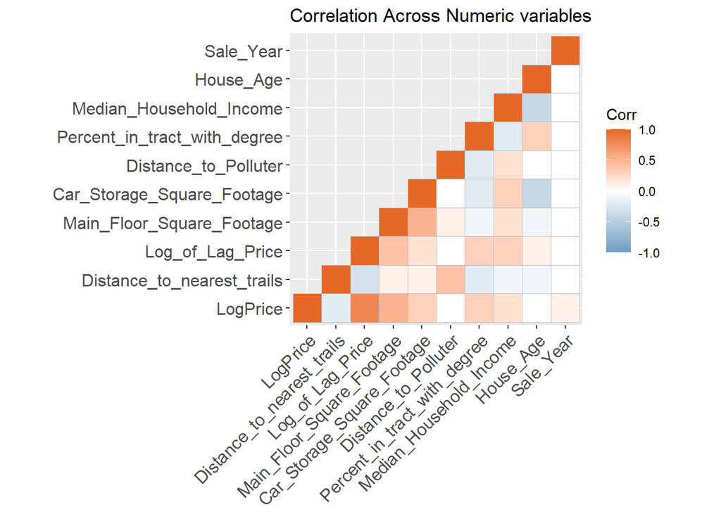

Figure 2 presents four scatter plots that illustrate the relationship between various features and the log of home prices. While there is a wide range in each category, it is clear that the prices do have a linear, if not perfectly linear, relationship with these indicators. The best and most powerful of these predictors is the log of the lag price; you can see that illustrated visually in Figure 2, as the prices cluster most closely along the plotline.

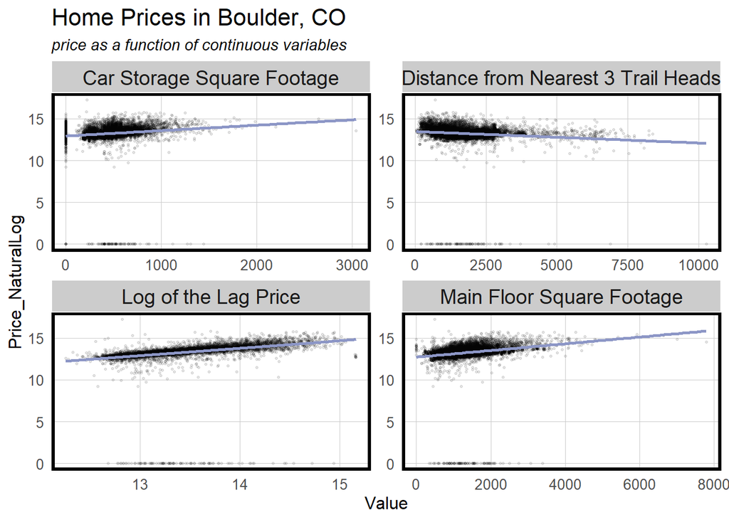

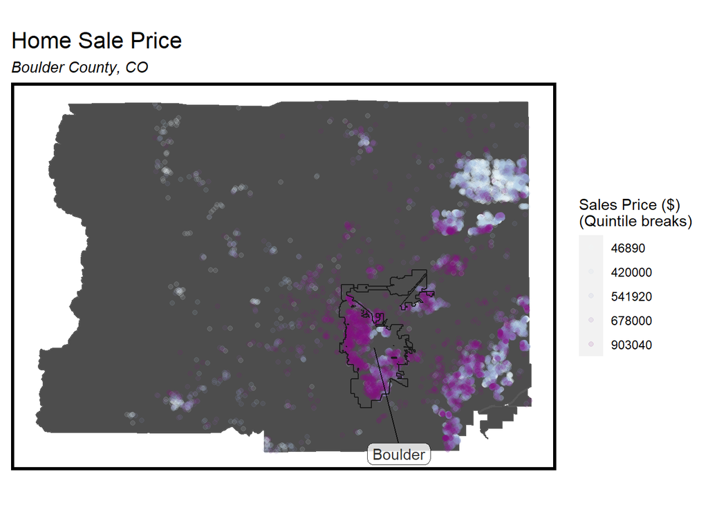

The maps below visualize how select indicators present themselves for properties throughout Boulder County. It is worth noting here that while the measure of proximity to polluters and proximity to trailheads spatially cluster, availability of car storage seems to have more variation throughout the county.

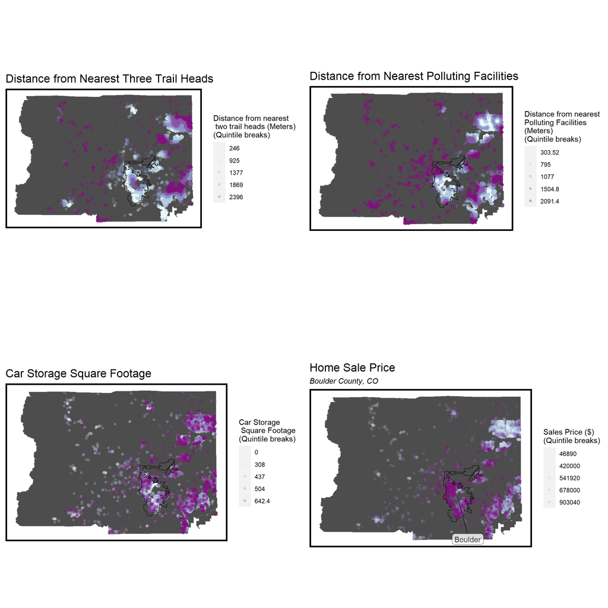

## Methods

The method we followed allowed us to identify what house features and neighborhood amenities influence the price of a house in a simple way. The statistical function we employed was a simple regression, Ordinary Least Squares.

Process for Developing a Model to Estimate Home Sale Price in Boulder Colorado.

Get and clean the data

Engineer predictor variables (e.g. distance from nearest polluting facility)

Explore the relationships between all variables (Figure 1)

Split our data into two groups, allowing us to train and then test (~75% train, ~25% test)

Narrow down predictors and incorporate them into a model

Train the model by creating it on the train data subset

Test the model on the test data subset, and evaluate its performance

Perform a Cross Validation test, evaluate the model’s performance

Back to Step 5, until we were happy with the results

After developing several indicators, our team split our data into two portions–allocating 75% to training a model and 25% to testing that model. We then created a correlation matrix of our continuous variables to see how these indicators interact and which combination might be best included in the model. From here, our team made a variety of models using these indicators and combinations of categorical variables. Experimenting in this way allowed us to determine which combination of categorical variables would enable us to create the most powerful model.

After testing on our test set and performing a cross validation test, we identified our strongest model. To further explore the weakness of our model, we evaluated whether we failed to account for various spatial factors. To do this, we investigated if the errors in our price predictions were clustered by Census Tract. If clustering of errors were apparent and proven to be statistically significant (Moran’s I), then our model would have lacked critical spatial predictors.

Additionally, we investigated our model for generalizability - that is to say, we investigated if our model did as equally well of job predicting under different conditions. Due to racial segregation in many U.S. cities, predicting home prices in majority white and majority-minority neighborhoods can be hard to accomplish with the same model if it is not generalizable. However, Boulder County is largely racially homogeneous. To test the generalizability of our model, we investigated whether the errors in our sale price predictions were roughly the same between houses located in neighborhoods with low/high median income and in areas with a population of senior citizens below or above the national average.

## Results: Effectiveness of Our Model

Table 4 shows our cross-validation results; comparing this with Table 2, the models are fairly similar. This indicates to us that the model we developed is reasonably accurate for our purposes. The histogram of errors from a 100-fold cross-validation cluster between 1.18 and 1.20—in the neighborhood of mean absolute error we found testing our model on our training data.

Coefficient-Level Estimates for a Model Fitted to Estimate Home Sale Price in Boulder Colorado.

| Predictor | Estimator | SE | t | p |
| --- | --- | --- | --- | --- |
| (Intercept) | -167.33328 | 8.90885 | -18.78281 | 0.00000 |
| Basement Type Variable | -0.07655 | 0.01042 | -7.34372 | 0.00000 |
| Drywall Variable | 0.02671 | 0.01416 | 1.88554 | 0.05939 |
| Roof Type Variable | -0.05455 | 0.00744 | -7.33602 | 0.00000 |
| Ranch House Variable | -0.15649 | 0.00798 | -19.61247 | 0.00000 |
| Radiant Heat Floor Variable | 0.30309 | 0.03475 | 8.72298 | 0.00000 |
| Exterior Wall Variable | 0.08195 | 0.01238 | 6.61864 | 0.00000 |
| In/Out of Boulder Valley School District | 0.09507 | 0.00807 | 11.77643 | 0.00000 |
| Distance from Nearest 3 Trail Heads | -0.00003 | 0.00000 | -7.58893 | 0.00000 |
| Log of the Lag Price | 0.65421 | 0.01040 | 62.90122 | 0.00000 |
| Main Floor Square Footage | 0.00022 | 0.00001 | 30.50632 | 0.00000 |
| Sale Year | 0.08501 | 0.00441 | 19.26539 | 0.00000 |
| Car Storage Square Footage | 0.00015 | 0.00002 | 8.15574 | 0.00000 |
| Percent of Population with Bachelors Degrees in Census Tract | 1.49614 | 0.21554 | 6.94132 | 0.00000 |
| Proximity to Two Nearest Polluting Facilities | 0.00000 | 0.00000 | -1.65357 | 0.09825 |
| Age of House | 0.00011 | 0.00017 | 0.64476 | 0.51910 |
| Median Household Income | 0.00000 | 0.00000 | -2.84221 | 0.00449 |

Table 2

$~$

| Mean.Absolute.Error..MAE. | Mean.Absolute.Percent.Error..MAPE. |
| --- | --- |
| 153938.4 | 19.97 |

Table 3

$~$

Coefficient-Level Estimates for a Model Fitted to Estimate Home Sale Price (LN) in Boulder Colorado.

[output not shown]

Table 4

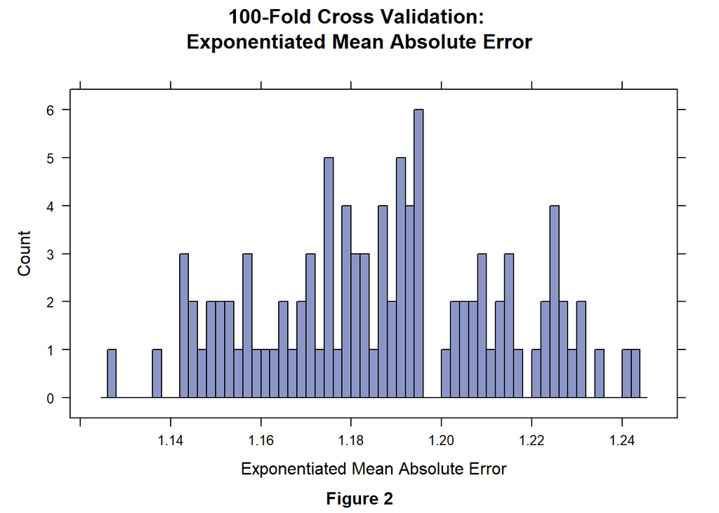

And plotting our predicted prices (Fig. 4)indicates that our model performs better at predicting the prices of homes with lower values. We suspect that this is the result of having transformed price data to make our model perform, on average, with a greater degree of accuracy.

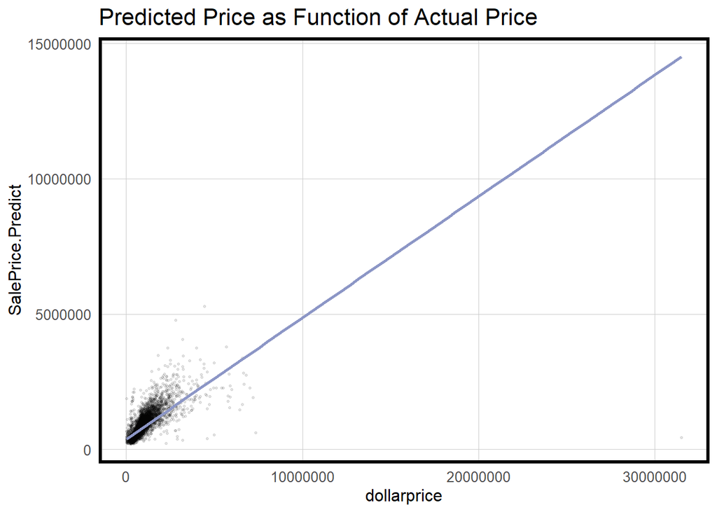

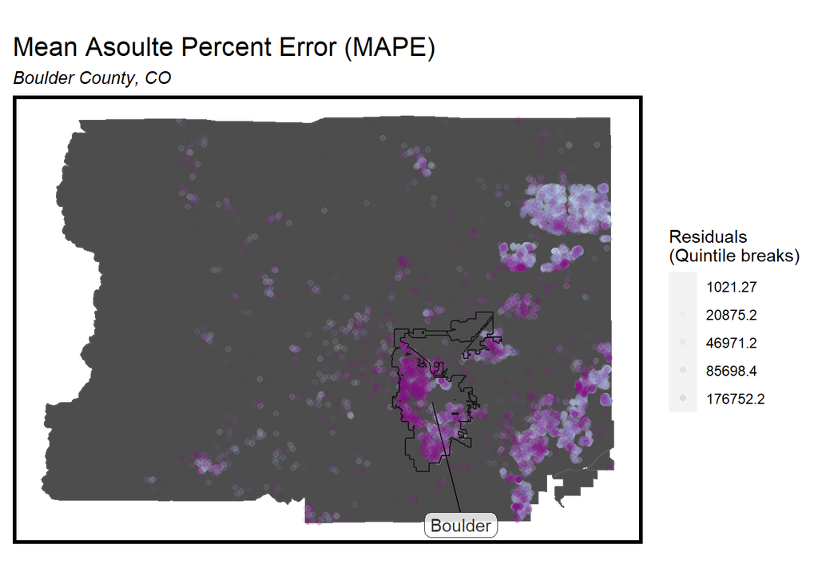

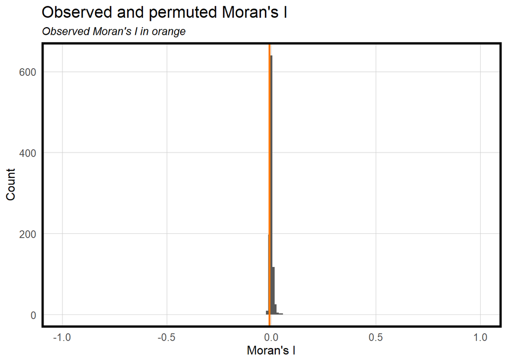

```
##
##  Monte-Carlo
##  simulation
##  of
##  Moran I
##
## data:  boulder.test.sf$SalePrice.Error
## weights: spatialWeights.test
## number of simulations + 1: 1000
##
## statistic
## =
## -0.0090961,
## observed
## rank =
## 56,
## p-value
## = 0.944
## alternative hypothesis: greater
```

Examining this map, it is clear that the model predicts lower home values in the mountainous western portion of the county. Further examination of our model will indicate what should be clear simply by comparing this map with the mapped prices of our training data: the model our team developed does not perform exceptionally well in the less urban portion of the county.

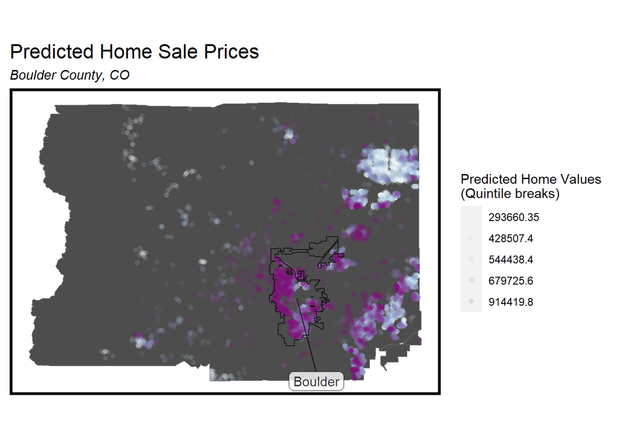

The map below indicates that our model performed better in the eastern rather than western portion of the county; this reflects that, on average, our model performed better in more populated areas. Future versions of this model could include indicators that might better account for variations in pricing and weighting of various variables depending on population density.

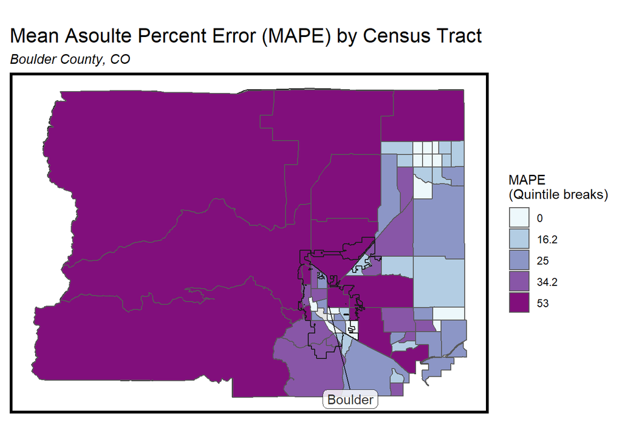

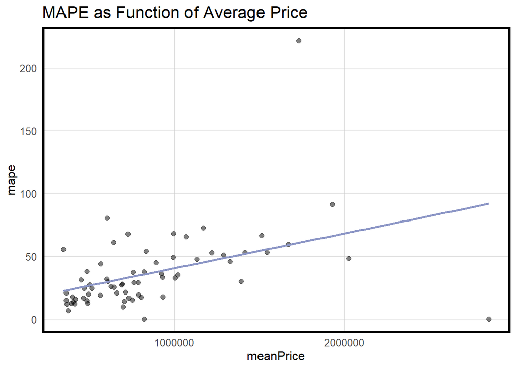

Further we examined whether our model was generalizable across different demographics in Boulder. The two categories we looked at were population density of senior citizens and median household income. For our seniors subgroups, we divided the census tracts in Boulder between tracts that had above the national average of seniors in their population and those that didn’t. For our income subgroups, we looked at census tracts with a median household income of above $32,000 and below.

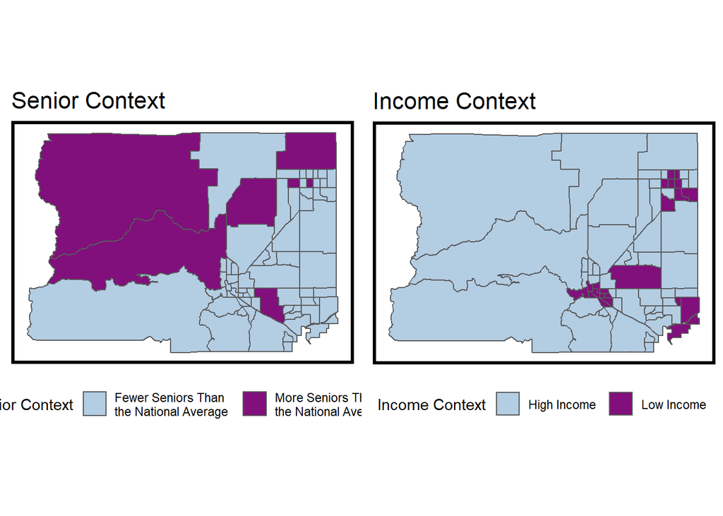

Ideally, the difference in error between the two categories in each subgroup should be roughly the same. The tables below show that we did a decent job at accounting for differences in income, but did not fare as well for senior populations greater than the national average.

Test set MAPE by neighborhood senior context

| seniorContext | mean.MAPE |
| --- | --- |
| Fewer Seniors Than the National Average | 17% |
| More Seniors Than the National Average | 25% |

Test set MAPE by neighborhood income context

| incomeContext | mean.MAPE |
| --- | --- |
| High Income | 18% |
| Low Income | 17% |

## Discussion

Is this an effective model?

The model we developed is less accurate than the models currently used by Zillow and should not be adopted. Nevertheless, our team is quite pleased with the success we have had developing a model that does not rely on crime statistics and hopes it may act as a starting point for further research.

We are particularly pleased with the work we have done developing a number of novel indicators. Among them:

Interesting Indicators Used in Developing a Model to Estimate Home Sale Price in Boulder Colorado.

[output not shown]

$~$ With these variables and a handful of others, our model can account for ~70% of the variation within our training set.

The key feature in our model is the measure we developed of the prices of nearby homes. Alone this feature is capable of predicting approximately fifty percent of the variation in home sales. At its most basic level, this indicator can account for how properties of similar values tend to cluster. Our team suspects that this clustering happens more in urbanized areas; this may help account for our model’s poor performance in the western parts of the county.

According to your maps, could you account the spatial variation in prices?

These errors are not evenly distributed throughout the county but are more extreme in less dense areas, and the model performs better in more dense areas. We suspect this may be due to indicators acting differently in urbanized and non-urbanized areas. For instance, lot sizes tend to be larger (and so square footage can also increase) in non-urban areas. Similarly, outside of cities, home prices may spatially cluster in ways that our current indicator measuring the sale price of nearby properties fails to account for properly.

## Conculsion

While we do not recommend that our model replace Zillow’s current model for Boulder County, we recommend that the indicators we have developed here be adopted. Further research into similar indicators may also allow Zillow to be a leader in moving away from relying on data generated by the police while continuing to offer a high-quality product.

This model could benefit from a more nuanced understanding of how price varies in less urbanized county areas. One approach to this would be developing separate models for use in areas with radically different population densities. It could also be useful to incorporate elevation data to help predict where homes fetch higher in prices because of exceptional views. This model could also benefit from fine-tuning existing features to develop more powerful indicators.